# BBM713 - Data Mining

2021 Fall Final Project Report

Doç. Dr. Burkay Genç and Some Other Guy

due 05/01/2022

# 1 Summary

# 2 Introduction

## 2.1 Data Source

We collect our own data. Our data collection setup consists of 2 main component: 1) Drone with controller on phone. 2) anemometer. With this setup, we have 2 separate data stream during collection.

We have [DJI Tello Drone](https://store.dji.com/product/tello?vid=38421) which is small and easy to use. Drone have various sensors and can be also used [programatically](https://github.com/dji-sdk/Tello-Python). We tried to move Drone programatically, however since it is not stable enough, we decided to move it manually. Available data to collect with Drone are pitch, roll, yaw, speeds of axis x/y/z, temperature, height, pressure, time, acceleration of axis x/y/z. Drone movement pipeline during data collection is given below:

1. Take off of the Drone
2. Moving te Drone forward approximately 10 meters
3. Bringing the Drone back in the same way
4. Going step 2 if there is enough charge else landing of the Drone

### 2.1.1 Step 1: Introducing Drone Data

```r
library(tidyr)
library(dplyr)
library(tibble)

set.seed(1024)


data_drone_path = "/home/emre/workspace/master/cmp713/project/data_final/data_drone.csv"
df_drone = as_tibble(read.csv(data_drone_path, header = TRUE))
head(df_drone, 10)
```

```
## # A tibble: 10 × 14
##      timestamp pitch  roll   yaw   vgx   vgy   vgz templ     h   bat  baro   agx
##          <dbl> <dbl> <dbl> <dbl> <dbl> <dbl> <dbl> <dbl> <dbl> <dbl> <dbl> <dbl>
##  1 1636886710.     0     0    58     0     0     0    69     0    90  969.   -14
##  2 1636886710.     0     0    58     0     0     0    69     0    90  969    -14
##  3 1636886710.     0     0    58     0     0     0    69     0    90  969    -13
##  4 1636886711.     0     0    58     0     0     0    69     0    90  969.   -14
##  5 1636886711.     0     0    58     0     0     0    69     0    90  969.   -13
##  6 1636886711.     0     0    58     0     0     0    69     0    90  969.   -12
##  7 1636886711.     0     0    58     0     0     0    69     0    90  969.   -14
##  8 1636886711.     0     0    58     0     0     0    69     0    90  969.   -13
##  9 1636886711.     0     0    58     0     0     0    69     0    90  969.   -13
## 10 1636886711.     0     0    58     0     0     0    69     0    90  969.   -13
## # … with 2 more variables: agy <dbl>, agz <dbl>
```

```r
for(i in df_drone %>% names()) {       # for-loop over columns
  if (i == "timestamp"){
    next
  }

  cat("$", i, "\n", sep = "")
  print(summary(df_drone[[i]]))
  cat("\n")
}
```

```
## $pitch
##     Min.  1st Qu.   Median     Mean  3rd Qu.     Max.
## -80.0000   0.0000   0.0000  -0.3796   1.0000   8.0000
##
## $roll
##    Min. 1st Qu.  Median    Mean 3rd Qu.    Max.
## -171.00    0.00    0.00  -18.02    9.00   83.00
##
## $yaw
##    Min. 1st Qu.  Median    Mean 3rd Qu.    Max.
##  -171.0   -10.0     0.0   -41.1     0.0    82.0
##
## $vgx
##      Min.   1st Qu.    Median      Mean   3rd Qu.      Max.
## -11.00000   0.00000   0.00000   0.06908   0.00000  25.00000
##
## $vgy
##      Min.   1st Qu.    Median      Mean   3rd Qu.      Max.
## -10.00000   0.00000   0.00000   0.01799   0.00000  10.00000
##
## $vgz
##    Min. 1st Qu.  Median    Mean 3rd Qu.    Max.
##   -13.0     0.0     3.0    34.3    71.0    81.0
##
## $templ
##    Min. 1st Qu.  Median    Mean 3rd Qu.    Max.
##   57.00   60.00   64.00   66.55   73.00   84.00
##
## $h
##    Min. 1st Qu.  Median    Mean 3rd Qu.    Max.
##  -50.00   26.00   68.00   88.81  150.00  180.00
##
## $bat
##    Min. 1st Qu.  Median    Mean 3rd Qu.    Max.
##    10.0    37.0    90.0   496.5   968.0   970.6
##
## $baro
##    Min. 1st Qu.  Median    Mean 3rd Qu.    Max.
##    59.0   137.0   959.4   572.9   967.6   970.3
##
## $agx
##    Min. 1st Qu.  Median    Mean 3rd Qu.    Max.
## -772.00  -29.00   -1.00  -11.55   17.00  508.00
##
## $agy
##    Min. 1st Qu.  Median    Mean 3rd Qu.    Max.
## -1309.0  -998.0   -77.0  -494.2    -3.0   788.0
##
## $agz
##       Min.    1st Qu.     Median       Mean    3rd Qu.       Max.
##      -2396       -999       -941  805700319 1636887639 1636893464
```

### 2.1.2 Step 2: Introducing Wind Data

```r
data_wind_path = "/home/emre/workspace/master/cmp713/project/data_final/data_wind.csv"
df_wind = as_tibble(read.csv(data_wind_path, header = TRUE))
head(df_wind, 10)
```

```
## # A tibble: 10 × 3
##     timestamp Wind.Speed  Temp
##         <dbl>      <dbl> <dbl>
##  1 1636892866        0.8  17.1
##  2 1636892867        0.4  17.1
##  3 1636892868        0.4  17.1
##  4 1636892870        0    17
##  5 1636892871        0    17
##  6 1636892872        0    17
##  7 1636892874        0    17
##  8 1636892875        0    16.9
##  9 1636892877        0    16.9
## 10 1636892878        0    16.9
```

```r
for(i in df_wind %>% names()) {       # for-loop over columns
  if (i == "timestamp"){
    next
  }

  cat("$", i, "\n", sep = "")
  print(summary(df_wind[[i]]))
  cat("\n")
}
```

```
## $Wind.Speed
##    Min. 1st Qu.  Median    Mean 3rd Qu.    Max.
##  0.0000  0.0000  1.0500  0.8793  1.4000  1.9800
##
## $Temp
##    Min. 1st Qu.  Median    Mean 3rd Qu.    Max.
##   12.30   12.80   13.50   13.96   15.00   17.10
```

### 2.1.3 Step 3: Combining 2 Data Source

Since frequencies of 2 stream are not same, when we combine streams, there was None values for some rows. For example if we got 20 Drone samples between 16:10:02- 16:10:03, we got only 1 wind sample. Hence we add combine these data by concating early Drone sample with Drone sample. Wind value of remaining samples of Drone data is set to “-1”.

```r
df_path = "/home/emre/workspace/master/cmp713/project/data_final/combined.csv"
df = as_tibble(read.csv(df_path, header = TRUE))
head(df, 10)
```

```
## # A tibble: 10 × 15
##      timestamp pitch  roll   yaw   vgx   vgy   vgz templ     h   bat  baro   agx
##          <dbl> <dbl> <dbl> <dbl> <dbl> <dbl> <dbl> <dbl> <dbl> <dbl> <dbl> <dbl>
##  1 1636886710.     0     0    58     0     0     0    69     0    90  969.   -14
##  2 1636886710.     0     0    58     0     0     0    69     0    90  969    -14
##  3 1636886710.     0     0    58     0     0     0    69     0    90  969    -13
##  4 1636886711.     0     0    58     0     0     0    69     0    90  969.   -14
##  5 1636886711.     0     0    58     0     0     0    69     0    90  969.   -13
##  6 1636886711.     0     0    58     0     0     0    69     0    90  969.   -12
##  7 1636886711.     0     0    58     0     0     0    69     0    90  969.   -14
##  8 1636886711.     0     0    58     0     0     0    69     0    90  969.   -13
##  9 1636886711.     0     0    58     0     0     0    69     0    90  969.   -13
## 10 1636886711.     0     0    58     0     0     0    69     0    90  969.   -13
## # … with 3 more variables: agy <dbl>, agz <dbl>, wind.speed <dbl>
```

### 2.1.4 Step 4: Data Analysis and Relations

Since wind affects behaviour of Drone, we want to show relation between some features.

#### 2.1.4.1 Wind Speed Histogram

:

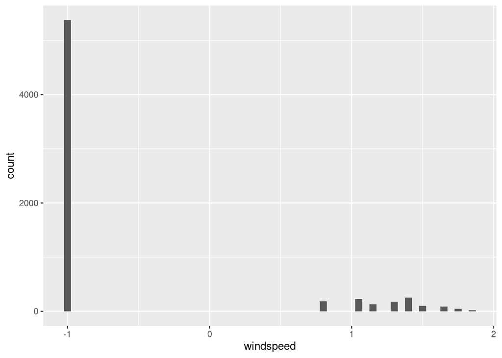

```r
library(ggplot2)

p1 <- ggplot(df, aes(x=wind.speed)) + geom_histogram(binwidth = 0.05) + xlab("windspeed")
p1
```

#### 2.1.4.2 Height Histogram

:

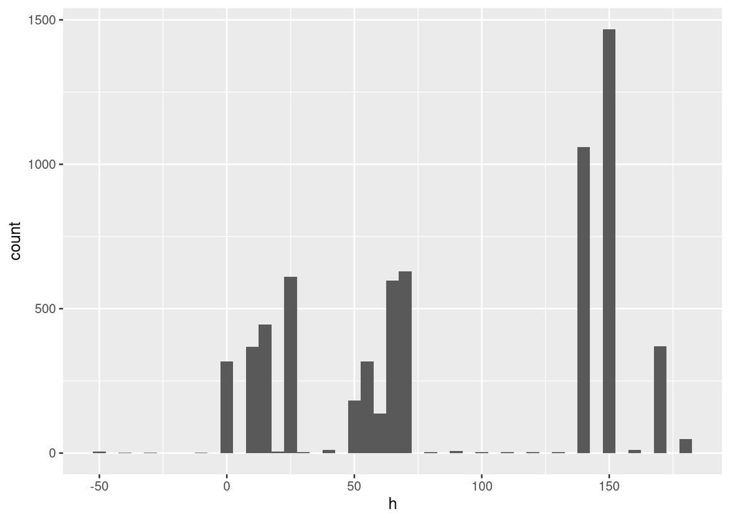

```r
ggplot(df, aes(x=h)) + geom_histogram(binwidth=5) + xlab("h")
```

#### 2.1.4.3 Speed Histograms

:

```r
library(gridExtra)
```

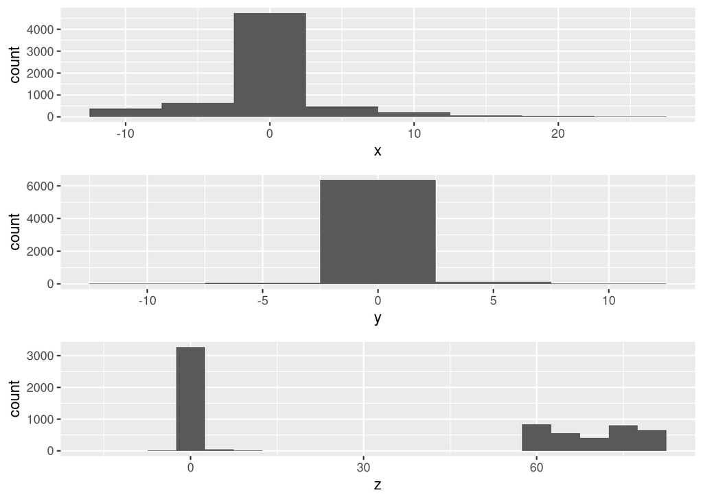

```r
p1 <- ggplot(df, aes(x=vgx)) + geom_histogram(binwidth=5) + xlab("x")
p2 <- ggplot(df, aes(x=vgy)) + geom_histogram(binwidth=5) + xlab("y")
p3 <- ggplot(df, aes(x=vgz)) + geom_histogram(binwidth=5) + xlab("z")

grid.arrange(grobs = list(p1, p2, p3),
            labels = c("axis x", "axis y", "axis z"),
            nrow=3)
```

#### 2.1.4.4 Acceleration Histograms

:

[figure not shown]

```r
p1 <- ggplot(df, aes(x=agx)) + geom_histogram(binwidth=5) + xlab("x")
p2 <- ggplot(df, aes(x=agy)) + geom_histogram(binwidth=5) + xlab("y")
p3 <- ggplot(df, aes(x=agz)) + geom_histogram(binwidth=5) + xlab("z")

grid.arrange(grobs = list(p1, p2, p3),
            labels = c("axis x", "axis y", "axis z"),
            nrow=3)
```

#### 2.1.4.5 Pitch/Roll/Yaw Histograms

:

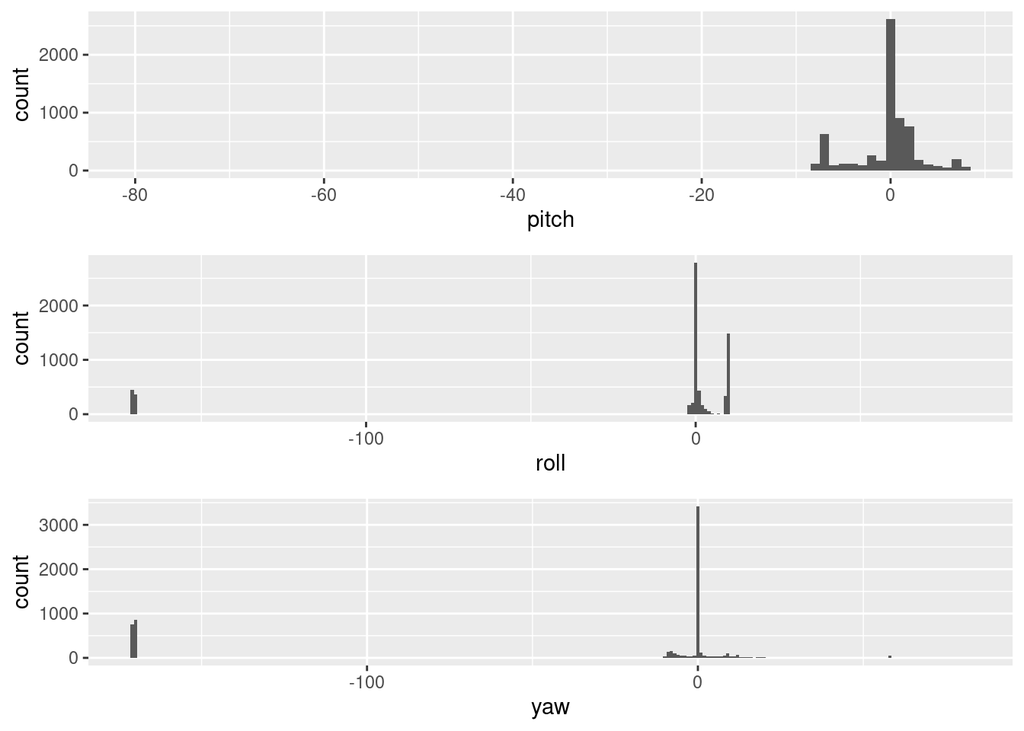

```r
p1 <- ggplot(df, aes(x=pitch)) + geom_histogram(binwidth=1) + xlab("pitch")
p2 <- ggplot(df, aes(x=roll)) + geom_histogram(binwidth=1) + xlab("roll")
p3 <- ggplot(df, aes(x=yaw)) + geom_histogram(binwidth=1) + xlab("yaw")

grid.arrange(grobs = list(p1, p2, p3),
            labels = c("axis x", "axis y", "axis z"),
            nrow=3)
```

#### 2.1.4.6 Relation between Wind Speed and pitch/roll/yaw

:

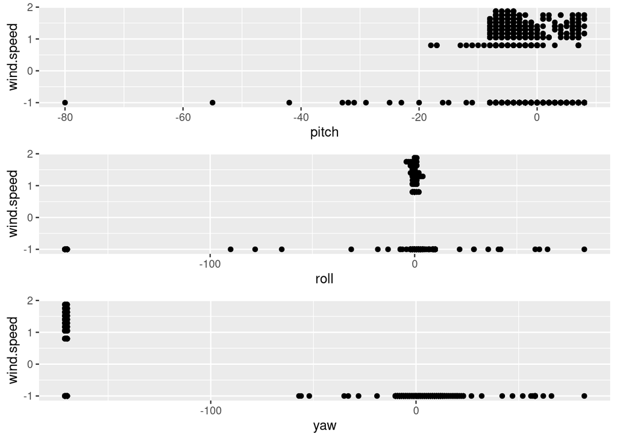

```r
p1 <- ggplot(df, aes(x=pitch, y=wind.speed)) + geom_point()
p2 <- ggplot(df, aes(x=roll, y=wind.speed)) + geom_point()
p3 <- ggplot(df, aes(x=yaw, y=wind.speed)) + geom_point()

grid.arrange(grobs = list(p1, p2, p3),
            labels = c("axis x", "axis y", "axis z"),
            nrow=3)
```

```r
# ggplot(df, aes(x=h, y=wind.speed, color=h_group)) + geom_point() + facet_wrap(~ h_group)
```

#### 2.1.4.7 Relation between Wind Speed and Speeds

:

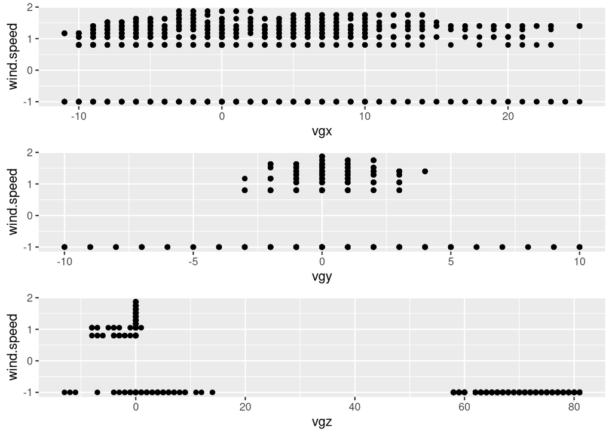

```r
p1 <- ggplot(df, aes(x=vgx, y=wind.speed)) + geom_point()
p2 <- ggplot(df, aes(x=vgy, y=wind.speed)) + geom_point()
p3 <- ggplot(df, aes(x=vgz, y=wind.speed)) + geom_point()

grid.arrange(grobs = list(p1, p2, p3),
            labels = c("axis x", "axis y", "axis z"),
            nrow=3)
```

```r
# ggplot(df, aes(x=h, y=wind.speed, color=h_group)) + geom_point() + facet_wrap(~ h_group)
```

#### 2.1.4.8 Relation between Wind Speed and Accelerations

:

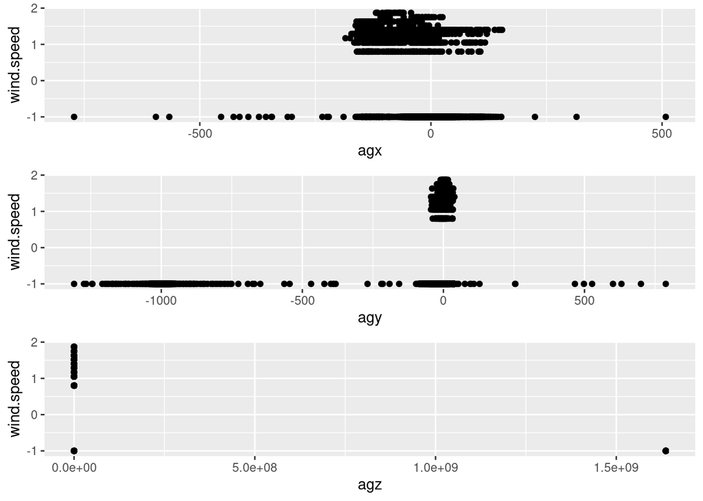

```r
p1 <- ggplot(df, aes(x=agx, y=wind.speed)) + geom_point()
p2 <- ggplot(df, aes(x=agy, y=wind.speed)) + geom_point()
p3 <- ggplot(df, aes(x=agz, y=wind.speed)) + geom_point()

grid.arrange(grobs = list(p1, p2, p3),
            labels = c("axis x", "axis y", "axis z"),
            nrow=3)
```

```r
# ggplot(df, aes(x=h, y=wind.speed, color=h_group)) + geom_point() + facet_wrap(~ h_group)
```

## 2.2 Related Work

# 3 Preprocessing

## 3.1 Cleaning

```r
library(knitr)
library(tidyr)
library(dplyr)
library(readr)
library(stringr)
library(lubridate)
# Standardization expect timestamp, date, wind speed
df_mean <- apply(df[2:14], 2, mean)
apply(df[2:14], 2, range)
```

```
##      pitch roll  yaw vgx vgy vgz templ   h   bat   baro  agx   agy        agz
## [1,]   -80 -171 -171 -11 -10 -13    57 -50  10.0  59.00 -772 -1309      -2396
## [2,]     8   83   82  25  10  81    84 180 970.6 970.33  508   788 1636893464
```

```r
df_scaled <- cbind(df %>% select(timestamp), df %>% select(-timestamp) %>% select(-wind.speed) %>% scale(), df %>% select(wind.speed))
df_scaled
```

```
## # A tibble: 6,615 × 15
##      timestamp pitch  roll   yaw     vgx     vgy    vgz templ     h    bat  baro
##          <dbl> <dbl> <dbl> <dbl>   <dbl>   <dbl>  <dbl> <dbl> <dbl>  <dbl> <dbl>
##  1 1636886710. 0.101 0.315  1.34 -0.0154 -0.0155 -0.973 0.305 -1.53 -0.877 0.984
##  2 1636886710. 0.101 0.315  1.34 -0.0154 -0.0155 -0.973 0.305 -1.53 -0.877 0.984
##  3 1636886710. 0.101 0.315  1.34 -0.0154 -0.0155 -0.973 0.305 -1.53 -0.877 0.984
##  4 1636886711. 0.101 0.315  1.34 -0.0154 -0.0155 -0.973 0.305 -1.53 -0.877 0.984
##  5 1636886711. 0.101 0.315  1.34 -0.0154 -0.0155 -0.973 0.305 -1.53 -0.877 0.984
##  6 1636886711. 0.101 0.315  1.34 -0.0154 -0.0155 -0.973 0.305 -1.53 -0.877 0.984
##  7 1636886711. 0.101 0.315  1.34 -0.0154 -0.0155 -0.973 0.305 -1.53 -0.877 0.984
##  8 1636886711. 0.101 0.315  1.34 -0.0154 -0.0155 -0.973 0.305 -1.53 -0.877 0.984
##  9 1636886711. 0.101 0.315  1.34 -0.0154 -0.0155 -0.973 0.305 -1.53 -0.877 0.984
## 10 1636886711. 0.101 0.315  1.34 -0.0154 -0.0155 -0.973 0.305 -1.53 -0.877 0.984
## # … with 6,605 more rows, and 4 more variables: agx <dbl>, agy <dbl>,
## #   agz <dbl>, wind.speed <dbl>
```

```r
apply(df_scaled, 2, range)
```

```
##       timestamp      pitch      roll       yaw       vgx       vgy       vgz
## [1,]        -15 -21.193127 -2.674442 -1.754564 -2.474380 -8.605763 -1.341674
## [2,] 1636893370   2.230455  1.766196  1.662845  5.573049  8.574856  1.324540
##          templ         h       bat       baro        agx       agy       agz
## [1,] -1.187723 -2.384622 -1.049299 -1.2770181 -13.298290 -1.639400 -0.984476
## [2,]  2.170462  1.566540  1.022741  0.9874318   9.085629  2.579972  1.015622
##      wind.speed
## [1,]      -1.00
## [2,]       1.87
```

```r
df
```

```
## # A tibble: 6,615 × 15
##      timestamp pitch  roll   yaw   vgx   vgy   vgz templ     h   bat  baro   agx
##          <dbl> <dbl> <dbl> <dbl> <dbl> <dbl> <dbl> <dbl> <dbl> <dbl> <dbl> <dbl>
##  1 1636886710.     0     0    58     0     0     0    69     0    90  969.   -14
##  2 1636886710.     0     0    58     0     0     0    69     0    90  969    -14
##  3 1636886710.     0     0    58     0     0     0    69     0    90  969    -13
##  4 1636886711.     0     0    58     0     0     0    69     0    90  969.   -14
##  5 1636886711.     0     0    58     0     0     0    69     0    90  969.   -13
##  6 1636886711.     0     0    58     0     0     0    69     0    90  969.   -12
##  7 1636886711.     0     0    58     0     0     0    69     0    90  969.   -14
##  8 1636886711.     0     0    58     0     0     0    69     0    90  969.   -13
##  9 1636886711.     0     0    58     0     0     0    69     0    90  969.   -13
## 10 1636886711.     0     0    58     0     0     0    69     0    90  969.   -13
## # … with 6,605 more rows, and 3 more variables: agy <dbl>, agz <dbl>,
## #   wind.speed <dbl>
```

```r
# Create Time Representations
# df$date = as_datetime(df$timestamp)
```

## 3.2 Imputation

## 3.3 Anomaly detection

## 3.4 Feature extraction

## 3.5 Dimensionality reduction

# 4 Methodology

## 4.1 Model training

## 4.2 Evaluation of results

# 5 Discussion